# Cost Parameters: Pricing What a Policy Does

Manuel D. Rossetti, PhD P.E.

## Agenda

- A rule has no cost: every cost term is a price times a quantity the system exhibits
- Checking the units, and the two inert terms
- The marginality test, and the classic failure it catches
- Unit cost, the holding cost $h = ic$, and which costs belong in the carrying charge
- The fixed order cost, the shortage costs $\pi$ and $b$, and the stocking position cost
- How accurate the parameters need to be, and the uncomfortable half of the answer

## A Rule Has No Cost

An inventory policy is a rule, and a rule has no cost. What costs money is the **behavior** the rule produces: orders placed at some rate, stock on a shelf for some time, demands arriving to an empty shelf. Every term of every model has one shape:

$$\text{cost rate} = \text{price} \times \text{quantity the system exhibits}$$

| Term | Price (you supply) | Quantity (the model computes) |
| --- | --- | --- |
| Ordering | $k$, dollars per order | order rate, orders per unit time |
| Holding | $h$, dollars per unit per unit time | average on hand $\bar{I}$, units |
| Backorder | $b$, dollars per unit per unit time | average backorders $\bar{B}$, units |
| Stockout | $\pi$, dollars per unit | rate of demand not filled, units per unit time |
| Purchase | $c$, dollars per unit | demand rate $\lambda$, units per unit time |
| Stocking position | $f$, dollars per item per location per unit time | *none* |

The quantities are properties of the system, and computing them is the technical content of the course. The **prices** are what you supply, and no amount of modeling will produce them.

## Check the Units, Row by Row

$$\begin{aligned}
\frac{\$}{\text{order}} \times \frac{\text{orders}}{\text{year}} &= \frac{\$}{\text{year}}
&&\text{ordering: a price times a rate}\\
\frac{\$}{\text{unit}\cdot\text{year}} \times \text{units} &= \frac{\$}{\text{year}}
&&\text{holding and backorder: a rate-price times a level}\\
\frac{\$}{\text{unit}} \times \frac{\text{units}}{\text{year}} &= \frac{\$}{\text{year}}
&&\text{stockout and purchase: a price times a rate}
\end{aligned}$$

Every row reduces to dollars per unit time, so the rows can be added. The holding and backorder prices are themselves rates, so they multiply a **level**: the commonest source of dimensional error in a first cost model.

**The purchase term is inert.** $c\lambda$ is identical under every policy when demand is not a decision, so it cannot influence the choice. Its symptom when included in a comparison: the alternatives all look suspiciously alike.

**Time units**

Every rate must use the same unit, and every price quoted per period must be converted on entry. A missed conversion is the error most likely to survive review, because the answer stays plausible while being wrong by a factor of 365.

## The Marginality Test

**The test**

A cost belongs in a parameter **only if it changes when the quantity that parameter multiplies changes.**

Applying it means naming the quantity first. $h$ multiplies $\bar{I}$, so a cost belongs in $h$ only if it rises when one more unit is held for one more unit of time. $k$ multiplies the order rate, so a cost belongs in $k$ only if it rises when one more order is placed. A cost that does neither is a **period cost**: real, possibly large, and irrelevant to the decision, because it is incurred identically under every policy.

**The classic failure** is a fully allocated warehouse cost per unit: lease, depreciation, heating and management divided by the units that passed through. That figure is correct as an accounting statement and wrong as a model input, because none of those costs change if you hold one more unit. It overstates holding cost and recommends ordering too often.

## Unit Cost and Holding Cost

**Unit cost** $c$ is the money tied up in one unit: normally the **latest acquisition cost**, not an internal transfer price or a customer-facing standard price. It enters the purchase term, which is inert, and the holding cost, which is not.

**Holding cost** $h$ is almost never estimated directly. Let $i$ represent the **carrying charge**, in dollars per dollar of inventory value per unit time:

$$h = i\,c, \qquad \text{for example } i = 0.20 \text{ a year: twenty cents to hold a dollar of stock for a year.}$$

The cost of holding is proportional to value, so one carrying charge serves a whole portfolio of differently priced items. Carrying charges are quoted annually, so a model in days uses $h = ic/365$.

$h$ multiplies **on-hand** inventory $\bar{I}$, not net inventory. The two differ exactly when the system is short, and that difference is charged separately, by $b$. Writing the holding term on net inventory assumes backorders are negligible.

## Which Costs Belong in the Carrying Charge?

| Component | Belongs in $i$? | Why |
| --- | --- | --- |
| Cost of capital | **Yes** | Money tied up in stock is unavailable for anything else; usually the floor |
| Obsolescence, deterioration, shrinkage | **Yes** | Exposure grows with the value held and how long it is held |
| Insurance and inventory taxes | **Yes, where assessed on value** | Insurers rate on declared value; many jurisdictions levy no inventory tax |
| Storage and space | **Only where marginal** | In an owned facility below capacity, one more unit costs nothing in space |
| Handling | **Rarely** | Receiving, picking and shipping scale with throughput, set by customers |

**Storage** is marginal in three cases: space rented per pallet position per period; a facility at or near capacity, where the right figure is the shadow price of capacity; and a lease that scales with the space used.

**Handling** volume is set by how much customers buy, not by the policy. Per-receipt handling belongs in $k$; per-unit handling in $c$; only stock-driven handling, such as relocation and congestion from holding too much, in $i$.

## The Fixed Order Cost

$k$ is the cost of placing one replenishment order, in dollars per order, independent of the order’s size: the requisition, its approval and transmission, receiving and inspecting the shipment, matching the invoice, paying it.

“Fixed” means fixed **with respect to the order quantity**, not with respect to the number of orders. A cost that scales with the units ordered belongs in $c$; a cost incurred once per order whatever its size is what $k$ is.

**Inbound freight** is the usual complication. The fixed portion of a shipment’s freight behaves exactly like an ordering cost and belongs in $k$, and it is often larger than it looks: below a carrier’s minimum, the bill does not vary with order size at all. The variable portion scales with units and is as inert as $c\lambda$. On a **scheduled** lane the truck departs whether or not you ordered, and no part of it is caused by your order.

## Stockout and Backorder Costs

**If the demand is lost**, the harm is a discrete event, once per unit not supplied:

$$\pi = \text{dollars per unit of demand not filled}, \qquad \text{cost rate } \pi\lambda_{\ell}.$$

**If the demand is backordered**, the harm is a **duration**: one unit owed for ten days is worse than one owed for one day, and a per-incident charge cannot express that.

$$b = \text{dollars per unit backordered per unit time}, \qquad \text{cost rate } b\,\bar{B}.$$

They are not interchangeable notation; they describe different physical situations. Some settings need both, a charge for the expedite a stockout triggers plus one for the waiting, but never both for the **same** consequence.

**Backorders and waiting are one measurement**

By Little’s law $\bar{B} = \lambda\overline{W}$, so $b\bar{B} = b\lambda\overline{W}$. An organization that cannot price a backorder can often state a tolerable wait, and that is enough.

## Stocking Position Cost

$f$ is the cost, per unit time, of carrying an item at a location **at all**: the catalog record, the reserved bin, the cycle counts it attracts, the planner attention it consumes. Conventionally dollars per item per location per year.

**This is not holding cost**

Holding cost scales with the quantity on hand. Stocking position cost is **independent of the quantity held**, the same for one unit or a thousand. Neither should be folded into the other.

It is easy to dismiss and it is not a detail. For a typical mid-value item it is often **larger** than the holding cost of the stock it houses, and because it multiplies nothing, it is the only term that penalizes stocking an item in more places. A model without it will forward-position marginal items no practical organization would stock.

## How Accurate Do These Need to Be?

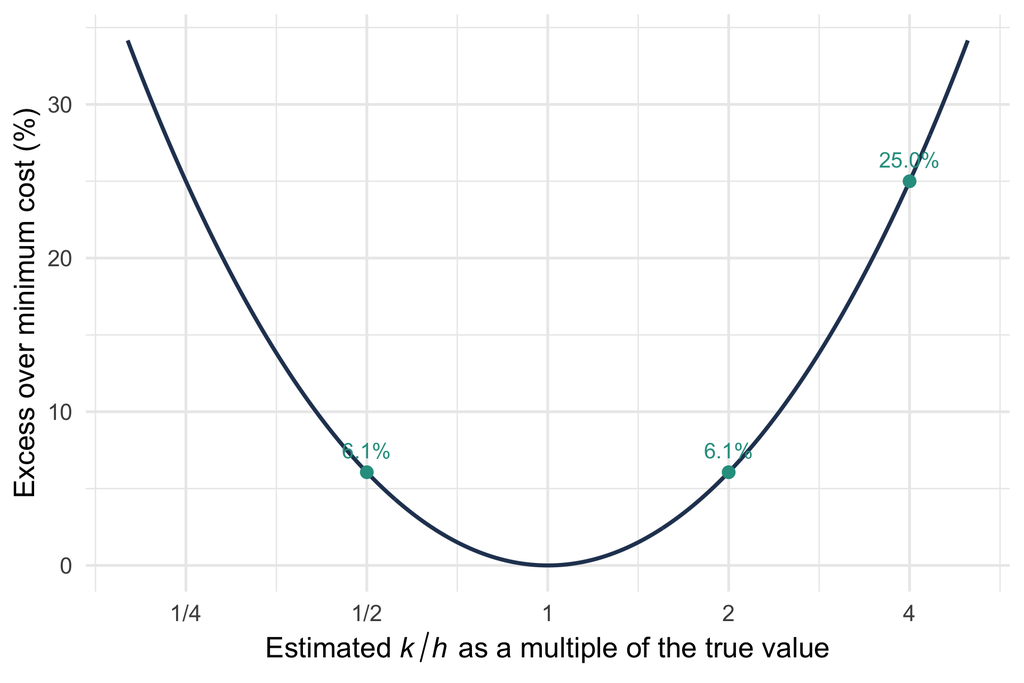

The order quantity depends on $k/h$ under a square root. Let $\theta$ represent the factor by which the estimated $k/h$ departs from the true value:

$$\begin{aligned}
\frac{Q}{Q^{*}} &= \sqrt{\theta}
&&\text{compressed}\\
\frac{C}{C^{*}} &= \frac{1}{2}\left(\sqrt{\theta} + \frac{1}{\sqrt{\theta}}\right)
&&\text{the penalty}\\
\theta = 2 &: \tfrac{1}{2}(1.414 + 0.707) = 1.061
&&\text{6}\%\\
\theta = 4 &: \tfrac{1}{2}(2 + 0.5) = 1.25
&&\text{25}\%
\end{aligned}$$

Read the curve from its minimum outward: it touches zero at $\theta = 1$ and is flat on both sides, and symmetric on the doubling scale. The square root is doing the protecting.

## The Uncomfortable Half

Because the cost surface is flat, a badly wrong parameter produces a cost that looks **perfectly acceptable** while the policy it recommends is substantially wrong. The model will not complain.

If the recommendation is a number of units to order, a 6% penalty may be tolerable. If the recommendation is which of two configurations to adopt, such as whether to stock an item at a location at all, a parameter error costing 6% can **flip the decision outright**. The flatness that protected the cost is what makes the comparison delicate.

Two consequences. Put estimation effort where the answer is sensitive, not uniformly. And when a parameter cannot be pinned down, do not defend a point estimate: report the value at which the recommendation changes.

## What We Did Today

**Every cost term is a price times a quantity,** and every row must reduce to dollars per unit time.

**The purchase term is inert,** and $f$ has no quantity at all.

**A cost belongs in a parameter only if it changes with the quantity that parameter multiplies;** period costs are real and irrelevant.

**$h = ic$ multiplies on-hand stock,** and storage and handling belong in $i$ only where marginal.

**$k$ is fixed with respect to order size;** $\pi$ prices an event and $b$ a duration.

**Errors in $k/h$ are compressed by a square root,** which protects the cost and endangers the comparison.

## For Next Time

**Read before next session:** *Estimating Cost Parameters from Standard Data* and *Performance Measures*.

Today’s material was *Cost Parameters*.

Next session:

- Building $c$, $i$ and $k$ from a ledger, with the marginality test deciding each line
- What to do instead of estimating a shortage cost, and the four double counts
- The total and relevant cost, and service measures that disagree on one history
- The general problem the rest of the course solves

Bring the carrying-components table. Next session fills it in from a real depot’s accounts.

⌂ Index